# Tugas Pertemuan 7

G1401231040 Fahmi Maulana Ardyanysah

2025-10-09

# Library yang diperlukan

```r
library(readxl)
library(dplyr)
library(ggplot2)
library(forecast)
library(tsibble)
library(tseries)
library(MASS)
library(TSA)
library(TTR)
library(aTSA)
library(graphics)
```

# Persiapan Data

## Pembacaan Data

```r
data <- read_excel("E:/(1) Projects/Semester 5/Metode Peramalan Deret Waktu/MPDW/Data/Data MPDWW.xlsx")
dataFahmi = data[541:720, ]
head(dataFahmi)
```

```
## # A tibble: 6 × 2
##   Periode   CO2
##     <dbl> <dbl>
## 1     541  389.
## 2     542  390.
## 3     543  391.
## 4     544  392.
## 5     545  393.
## 6     546  392.
```

```r
# Mengubah data menjadi objek time series (ts)
ts_Fahmi <- ts(dataFahmi$CO2)
head(ts_Fahmi)
```

```
## Time Series:
## Start = 1
## End = 6
## Frequency = 1
## [1] 388.55 390.08 391.02 392.39 393.24 392.26
```

## Membagi data menjadi data train dan data test

```r
n <- length(ts_Fahmi)
nTrain <- round(n * 0.80)

print(paste("Total Observasi:", n))
```

```
## [1] "Total Observasi: 180"
```

```r
print(paste("Jumlah Observasi Training (80%):", nTrain))
```

```
## [1] "Jumlah Observasi Training (80%): 144"
```

```r
DataTrain <- ts_Fahmi[1:nTrain]
DataTest <- ts_Fahmi[(nTrain + 1):n]

print(paste("Panjang Data Train:", length(DataTrain)))
```

```
## [1] "Panjang Data Train: 144"
```

```r
print(paste("Panjang Data Test:", length(DataTest)))
```

```
## [1] "Panjang Data Test: 36"
```

## Plot Data

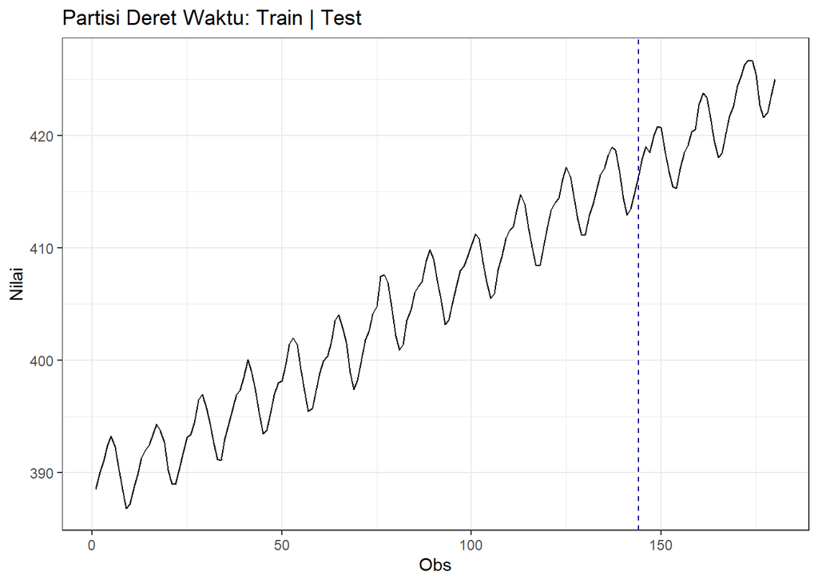

```r
# Membuat Plot Data
plot_dataFahmi <- ts_Fahmi |>
  as_tsibble() |>
  ggplot(aes(x = index, y = value)) +
  geom_line() +
  theme_bw() +
  xlab("Obs") +
  ylab("Nilai") +
  geom_vline(xintercept = 144, linetype = "dashed", color = "darkblue") +
  ggtitle("Partisi Deret Waktu: Train | Test")

plot_dataFahmi
```

Dari plot tersebut, terlihat bahwa data yang saya miliki **tidak stasioner dalam rataan, stasioner dalam ragam, dan memiliki tren naik**.

## Cek rataan data train stasioner dengan Plot ACF

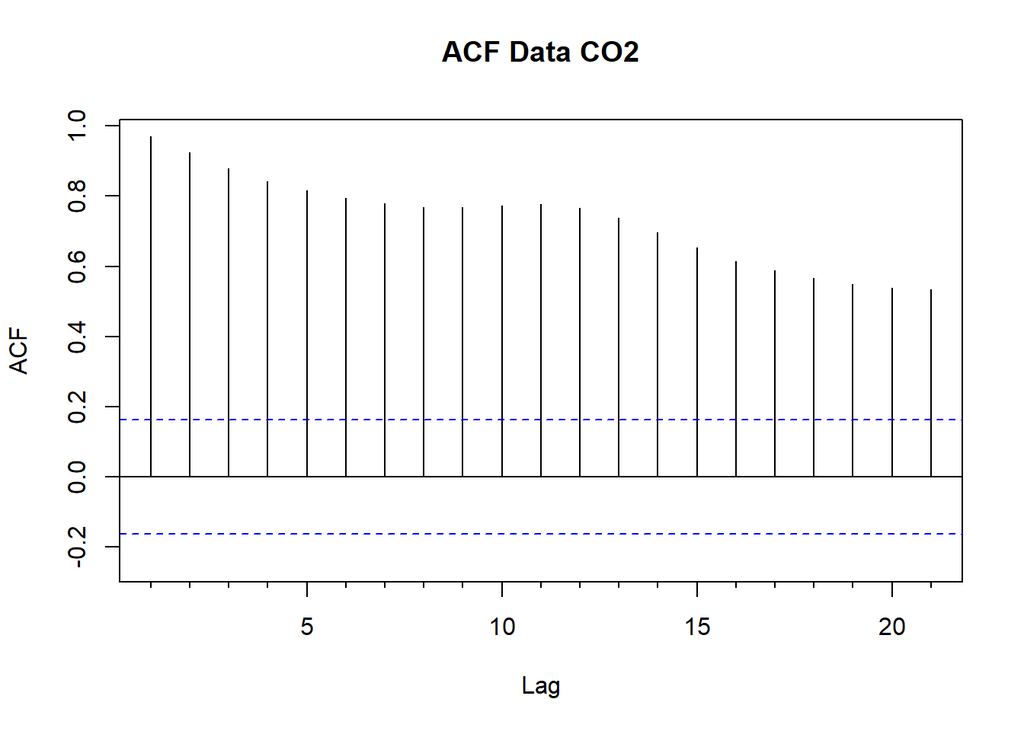

```r
Acf(DataTrain, main="ACF Data CO2")
```

Plot ini menunjukkan bahwa data train saya memiliki nilai korelasi tinggi dan **tidak stasioner** dalam rataan karena adanya tren naik.

## Cek rataan data train stasioner dengan Uji ADF

$H_0$ : Data train tidak stasioner dalam rataan

$H_1$ : Data train stasioner dalam rataan

```r
tseries::adf.test(DataTrain)
```

```
##
##  Augmented Dickey-Fuller Test
##
## data:  DataTrain
## Dickey-Fuller = -12.195, Lag order = 5, p-value = 0.01
## alternative hypothesis: stationary
```

Berdasarkan uji ADF tersebut, didapat *p-value* yang lebih kecil dari 0.01 yang lebih kecil dari taraf nyata 5% sehingga tolak $H_0$ dan menandakan bahwa data train **stasioner dalam rataan**.

Kendati demikian, uji ADF adalah uji yang memasukkan unsur tren dalam model pengujiannya, sehingga jika suatu data memiliki tren tertentu, maka ADF akan ‘mengoreksi’ tren tersebut secara otomatis untuk menyatakan apakah data tersebut memiliki rataan yang tidak stasioner dan “melenceng” dari trennya. Oleh karena itu, walaupun uji ADF menyatakan bahwa data train saya stasioner dalam rataan, saya lebih mempercayai *plot time series* dan *plot ACF* yang benar-benar menunjukkan bahwa **data train saya tidak stasioner dalam rataan** (tidak peduli dengan trennya).

## Cek ragam data train stasioner dengan Plot Boxcox

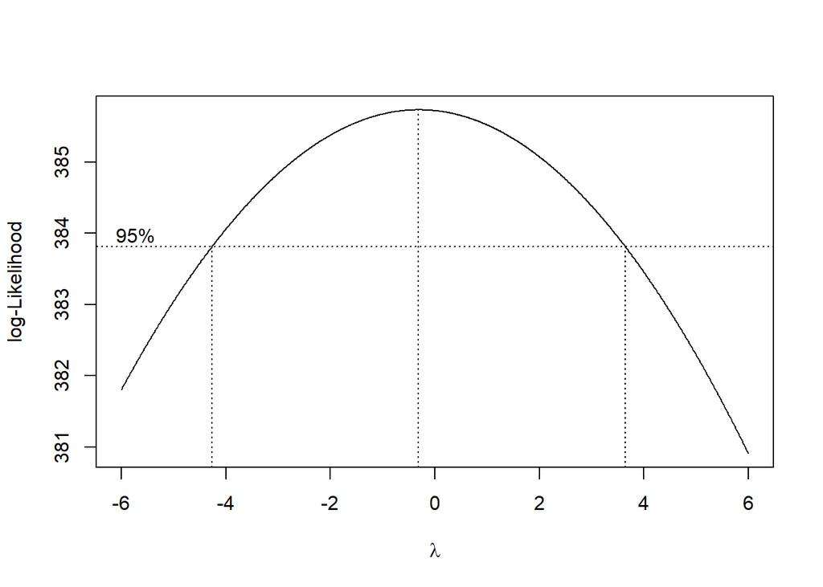

```r
index <- seq(1, 144)

# Box-Cox
bc <- boxcox(DataTrain ~ index, lambda = seq(-6, 6, by = 0.01)
)
```

```r
lambda <- bc$x[which.max(bc$y)]
lambda
```

```
## [1] -0.31
```

```r
# Selang kepercayaan 95% untuk lambda
ci_lambda <- bc$x[bc$y > max(bc$y) - 0.5 * qchisq(0.95, 1)]

# Batas bawah dan batas atas
ci_lower <- min(ci_lambda)
ci_upper <- max(ci_lambda)

c(Batas_Bawah = ci_lower, Batas_Atas = ci_upper)
```

```
## Batas_Bawah  Batas_Atas
##       -4.26        3.64
```

Gambar di atas menunjukkan nilai λ optimum (rounded value) sebesar **-0.31** dan selang kepercayaan 95% nilai memiliki batas bawah **-4.26** dan batas atas **3.64**. Selang tersebut memuat nilai satu sehingga dapat dikatakan bahwa data train saya **stasioner dalam ragam** pada taraf nyata 5%.

## Kesimpulan dari data

Data train saya **tidak stasioner dalam rataan, tetapi stasioner dalam ragam** pada taraf nyata 5%.

## Penanganan pada data train

### Differencing pertama

```r
# Differencing pertama pada DataTrain
DataTrain_diff1 <- diff(DataTrain, differences = 1)
```

#### Plot hasil differencing pertama

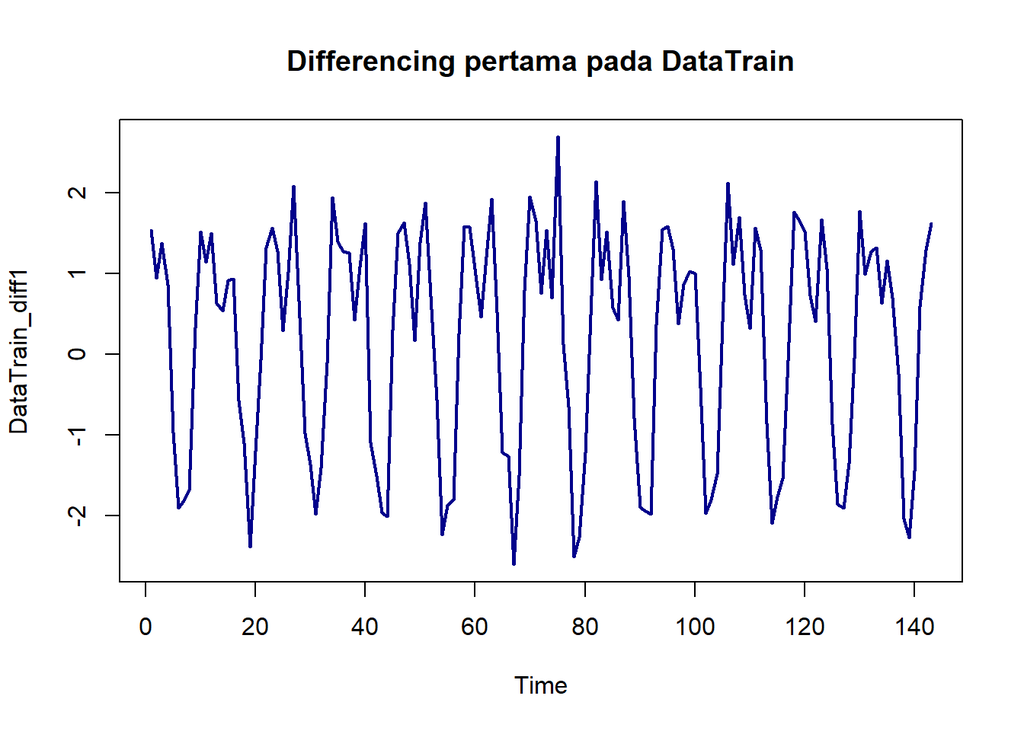

```r
ts.plot(DataTrain_diff1,
        main = "Differencing pertama pada DataTrain",
        col = "darkblue", lwd = 2)
```

Plot hasil differencing (Differencing pertama pada DataTrain) menunjukkan data train sekarang berfluktuasi di sekitar nilai nol.

Tren naik sudah hilang karena saya telah melakukan differencing orde 1.

#### Plot ACF hasil differencing pertama

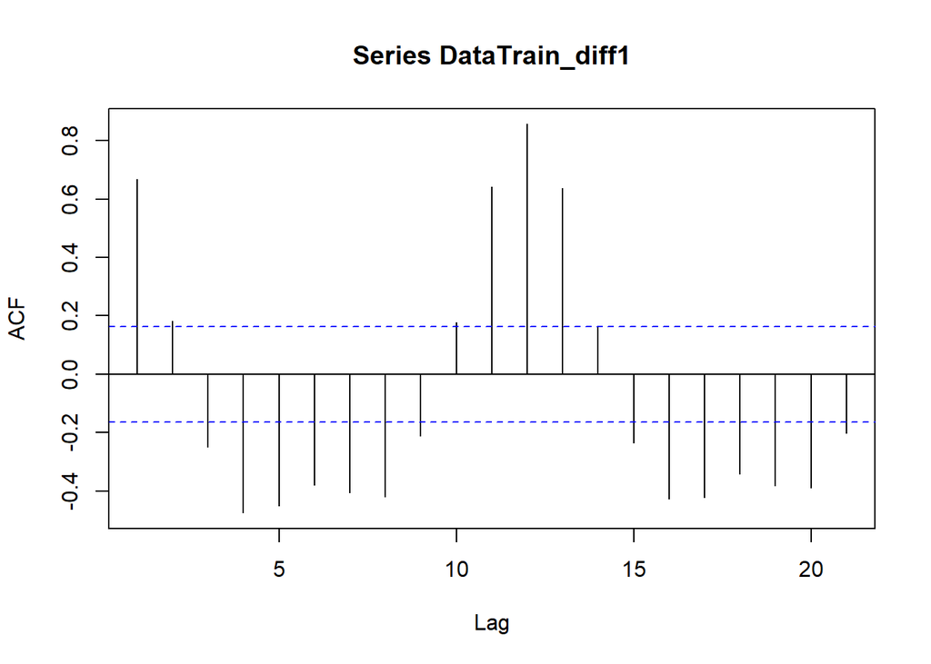

```r
acf(DataTrain_diff1)
```

#### Uji ADF hasil differencing pertama

$H_0$ : Data train hasil differencing pertama tidak stasioner dalam rataan

$H_1$ : Data train hasil differencing pertama stasioner dalam rataan

```r
tseries::adf.test(DataTrain_diff1)
```

```
##
##  Augmented Dickey-Fuller Test
##
## data:  DataTrain_diff1
## Dickey-Fuller = -8.1411, Lag order = 5, p-value = 0.01
## alternative hypothesis: stationary
```

Berdasarkan uji ADF tersebut, didapat *p-value* yang lebih kecil dari 0.01 yang lebih kecil dari taraf nyata 5% sehingga tolak $H_0$ dan menandakan bahwa data train hasil differencing pertama **stasioner dalam rataan**. Hal ini sesuai dengan hasil eksplorasi menggunakan plot time series dan plot ACF terhadap data train hasil differencing pertama.

### Kesimpulan Hasil Differencing pertama

Setelah dilakukan differencing pertama, **data train menjadi stasioner dalam rataan dan stasioner dalam ragam** pada taraf nyata 5%.

# Permodelan ARIMA

## Identifikasi Orde ARIMA (p,d,q)

### Plot PACF

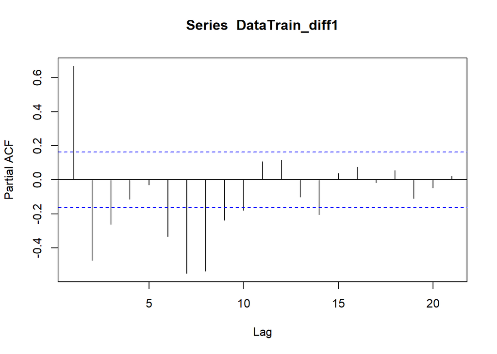

```r
pacf(DataTrain_diff1)
```

### Orde diferensiasi

Orde diferensiasi yang dilakukan pada data train adalah 1, sehingga **d = 1**.

### Plot ACF

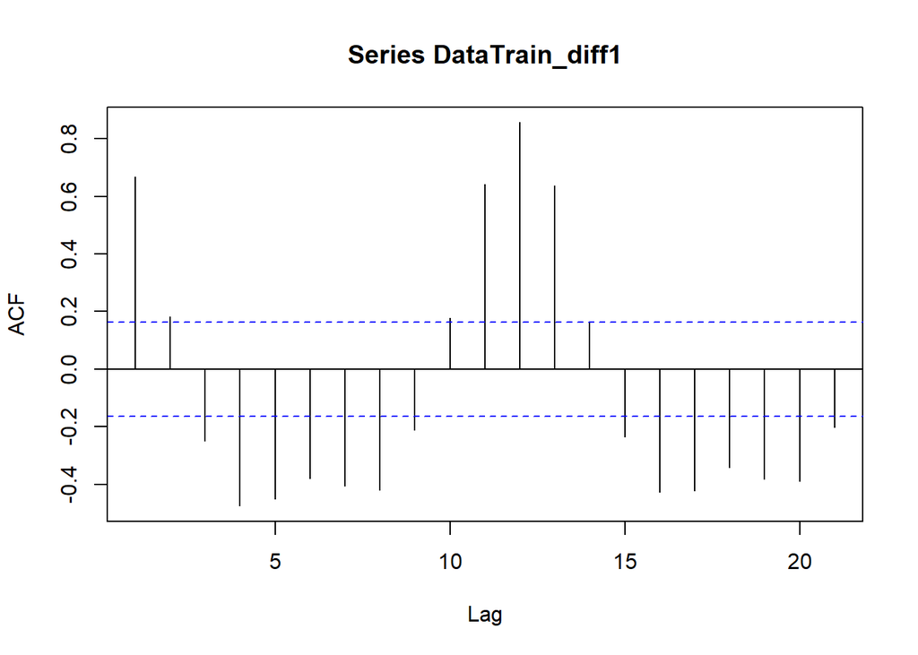

```r
acf(DataTrain_diff1)
```

### Plot EACF

```r
eacf(DataTrain_diff1)
```

```
## AR/MA
##   0 1 2 3 4 5 6 7 8 9 10 11 12 13
## 0 x x x x x x x x x x x  x  x  o
## 1 x x x x o o o x x o x  x  x  x
## 2 x o o x o o o x o o o  x  o  o
## 3 x o o x x o o x o o o  x  x  o
## 4 x o o o o o o x o o o  o  o  o
## 5 o x x x o o o x o o o  o  o  o
## 6 x x o x o o o x x x o  o  o  o
## 7 x x o o o x x o o o o  o  o  o
```

Dari plot EACF, diperoleh kandidat model ARIMA(1,1,4), ARIMA(2,1,1), ARIMA(2,1,2), dan ARIMA(3,1,1).

## Estimasi Model ARIMA dan Perbandingannya

### Model ARIMA(1,1,4)

```r
arima114 <- Arima(DataTrain, order = c(1,1,4), method="ML")
summary(arima114)
```

```
## Series: DataTrain
## ARIMA(1,1,4)
##
## Coefficients:
##          ar1     ma1      ma2      ma3      ma4
##       0.6180  0.1517  -0.0529  -0.2285  -0.4606
## s.e.  0.0969  0.0955   0.0742   0.0689   0.0662
##
## sigma^2 = 0.7505:  log likelihood = -180.48
## AIC=372.95   AICc=373.57   BIC=390.73
##
## Training set error measures:
##                     ME      RMSE       MAE        MPE      MAPE      MASE
## Training set 0.1800996 0.8480624 0.6906703 0.04466952 0.1715412 0.5571178
##                    ACF1
## Training set 0.03607772
```

```r
lmtest::coeftest(arima114)
```

```
##
## z test of coefficients:
##
##      Estimate Std. Error z value  Pr(>|z|)
## ar1  0.618047   0.096919  6.3769 1.807e-10 ***
## ma1  0.151687   0.095478  1.5887 0.1121271
## ma2 -0.052921   0.074234 -0.7129 0.4759125
## ma3 -0.228513   0.068855 -3.3187 0.0009042 ***
## ma4 -0.460599   0.066157 -6.9622 3.350e-12 ***
## ---
## Signif. codes:  0 '***' 0.001 '**' 0.01 '*' 0.05 '.' 0.1 ' ' 1
```

Parameter MA(1) dan MA(2) Model ARIMA(1,1,4) tidak signifikan, model terlalu kompleks.

### Model ARIMA(2,1,1)

```r
arima211 <- Arima(DataTrain, order = c(2,1,1), method="ML")
summary(arima211)
```

```
## Series: DataTrain
## ARIMA(2,1,1)
##
## Coefficients:
##          ar1      ar2      ma1
##       1.4817  -0.7926  -0.7436
## s.e.  0.0551   0.0500   0.0546
##
## sigma^2 = 0.7038:  log likelihood = -177.04
## AIC=362.09   AICc=362.38   BIC=373.94
##
## Training set error measures:
##                     ME      RMSE       MAE        MPE      MAPE      MASE
## Training set 0.2318395 0.8271886 0.6411491 0.05737683 0.1591164 0.5171724
##                     ACF1
## Training set -0.04855028
```

```r
lmtest::coeftest(arima211)
```

```
##
## z test of coefficients:
##
##      Estimate Std. Error z value  Pr(>|z|)
## ar1  1.481723   0.055078  26.902 < 2.2e-16 ***
## ar2 -0.792614   0.049958 -15.866 < 2.2e-16 ***
## ma1 -0.743630   0.054628 -13.613 < 2.2e-16 ***
## ---
## Signif. codes:  0 '***' 0.001 '**' 0.01 '*' 0.05 '.' 0.1 ' ' 1
```

Seluruh parameter Model ARIMA(2,1,1) signifikan, model valid.

### Model ARIMA(2,1,2)

```r
arima212 <- Arima(DataTrain, order = c(2,1,2), method="ML")
summary(arima212)
```

```
## Series: DataTrain
## ARIMA(2,1,2)
##
## Coefficients:
##          ar1      ar2      ma1     ma2
##       1.0239  -0.7586  -0.3395  0.7194
## s.e.  0.0641   0.0933   0.1380  0.1862
##
## sigma^2 = 0.756:  log likelihood = -181.92
## AIC=373.83   AICc=374.27   BIC=388.64
##
## Training set error measures:
##                    ME      RMSE       MAE        MPE      MAPE      MASE
## Training set 0.101851 0.8542391 0.6891988 0.02533926 0.1709728 0.5559309
##                   ACF1
## Training set 0.1537189
```

```r
lmtest::coeftest(arima212)
```

```
##
## z test of coefficients:
##
##      Estimate Std. Error z value  Pr(>|z|)
## ar1  1.023872   0.064098 15.9736 < 2.2e-16 ***
## ar2 -0.758585   0.093321 -8.1288 4.337e-16 ***
## ma1 -0.339476   0.137957 -2.4607 0.0138653 *
## ma2  0.719393   0.186186  3.8639 0.0001116 ***
## ---
## Signif. codes:  0 '***' 0.001 '**' 0.01 '*' 0.05 '.' 0.1 ' ' 1
```

Seluruh parameter Model ARIMA(2,1,2) signifikan, model valid.

### Model ARIMA(3,1,1)

```r
arima311 <- Arima(DataTrain, order = c(3,1,1), method="ML")
summary(arima311)
```

```
## Series: DataTrain
## ARIMA(3,1,1)
##
## Coefficients:
##          ar1      ar2     ar3      ma1
##       1.5227  -0.8600  0.0445  -0.7564
## s.e.  0.1027   0.1516  0.0946   0.0586
##
## sigma^2 = 0.7079:  log likelihood = -176.93
## AIC=363.86   AICc=364.3   BIC=378.68
##
## Training set error measures:
##                     ME      RMSE      MAE        MPE      MAPE      MASE
## Training set 0.2298795 0.8266032 0.640484 0.05689525 0.1589627 0.5166359
##                     ACF1
## Training set -0.07560212
```

```r
lmtest::coeftest(arima311)
```

```
##
## z test of coefficients:
##
##      Estimate Std. Error  z value  Pr(>|z|)
## ar1  1.522670   0.102748  14.8195 < 2.2e-16 ***
## ar2 -0.859976   0.151604  -5.6725 1.407e-08 ***
## ar3  0.044521   0.094578   0.4707    0.6378
## ma1 -0.756425   0.058630 -12.9018 < 2.2e-16 ***
## ---
## Signif. codes:  0 '***' 0.001 '**' 0.01 '*' 0.05 '.' 0.1 ' ' 1
```

Parameter AR(3) Model ARIMA(3,1,1) tidak signifikan, model terlalu kompleks.

### Tabel perbandingan 4 model ARIMA

```r
comparison_table <- data.frame(
  Model = c("ARIMA(1,1,4)", "ARIMA(2,1,1)", "ARIMA(2,1,2)", "ARIMA(3,1,1)"),
  AIC = c(arima114$aic, arima211$aic, arima212$aic, arima311$aic),
  BIC = c(arima114$bic, arima211$bic, arima212$bic, arima311$bic)
)

comparison_table[order(comparison_table$AIC), ]
```

```
##          Model      AIC      BIC
## 2 ARIMA(2,1,1) 362.0881 373.9395
## 4 ARIMA(3,1,1) 363.8646 378.6789
## 1 ARIMA(1,1,4) 372.9511 390.7282
## 3 ARIMA(2,1,2) 373.8305 388.6448
```

Berdasarkan signifikansi parameter dan nilai AIC, diperoleh model ARIMA(2,1,1) sebagai kandidat model terbaik untuk dilakukan peramalan lebih lanjut karena seluruh parameternya signifikan dan memiliki nilai AIC yang paling kecil.

## Evaluasi model ARIMA(2,1,1)

### Uji asumsi sisaan model ARIMA(2,1,1)

#### Uji normalitas sisaan model ARIMA(2,1,1)

$H_0$ : Sisaan menyebar normal

```
## [1] 76 88
```

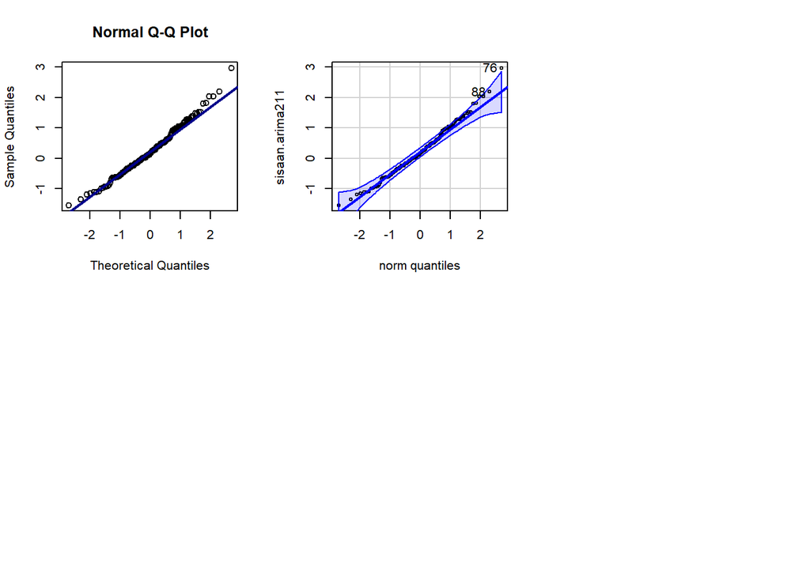

```r
#Eksplorasi
sisaan.arima211 <- arima211$residuals

par(mfrow=c(2,3))

qqnorm(sisaan.arima211)
qqline(sisaan.arima211, col = "darkblue", lwd = 2)
car::qqPlot(sisaan.arima211)
```

##### Uji Formal ktest

```r
ks.test(arima211$residuals,"pnorm")
```

```
##
##  Asymptotic one-sample Kolmogorov-Smirnov test
##
## data:  arima211$residuals
## D = 0.15664, p-value = 0.001706
## alternative hypothesis: two-sided
```

Berdasarkan QQ Plot dan k-test, terdapat cukup bukti untuk menyatakan bahwa sisaan dari model ARIMA(2,1,1) tidak menyebar normal pada taraf nyata 5%.

#### Uji Homoskedastisitas: Plot sisaan terhadap periode model ARIMA(2,1,1)

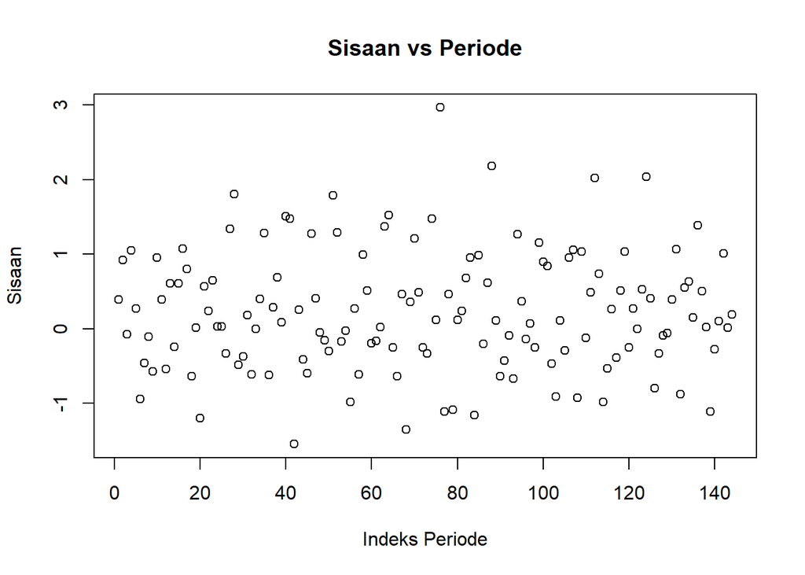

```r
par(mfrow=c(1,1))
plot(c(1:length(sisaan.arima211)), sisaan.arima211,
     main = "Sisaan vs Periode", xlab = "Indeks Periode", ylab = "Sisaan")
```

Berdasarkan plot sisaan vs. periode di atas, dapat dilihat bahwa sisaan cenderung menyebar secara acak sepanjang periode. Oleh karena itu, ragam sisaan dapat bahwa model ini memenuhi asumsi ragam sisaan homogen.

#### Uji independensi sisaan model ARIMA(2,1,1)

$H_0$ : Sisaan saling bebas

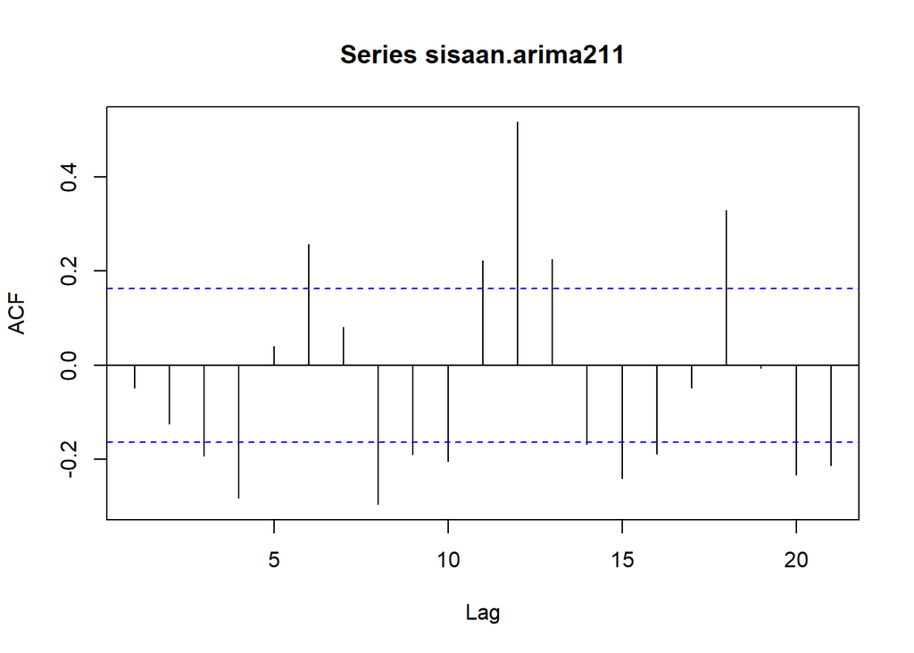

```r
# ACFF dan PACF sisaan
par(mfrow = c(1,1))
acf(sisaan.arima211)
```

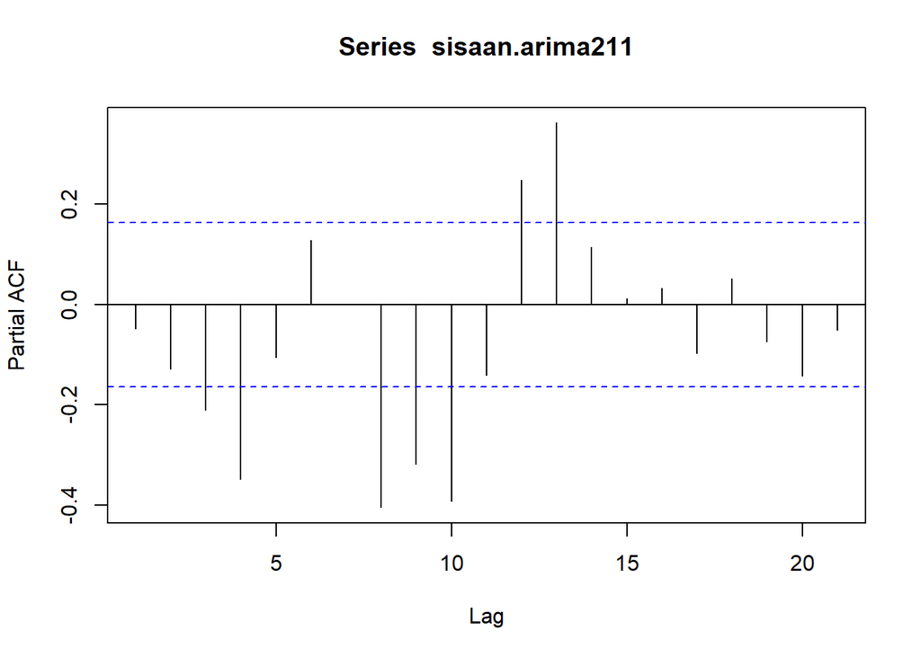

```r
pacf(sisaan.arima211)
```

##### Uji Box_Ljung

```r
Box.test((sisaan.arima211)^2, type = "Ljung")
```

```
##
##  Box-Ljung test
##
## data:  (sisaan.arima211)^2
## X-squared = 0.020695, df = 1, p-value = 0.8856
```

### Overfitting model ARIMA(2,1,1)

menaikkan orde AR(p) dan MA(q) dari model ARIMA(2,1,1) untuk melihat apakah terdapat model lain yang lebih baik dari model saat ini.

#### Model ARIMA(3,1,1)

```r
arima311 <- Arima(DataTrain, order = c(3,1,1), method="ML")
summary(arima311)
```

```
## Series: DataTrain
## ARIMA(3,1,1)
##
## Coefficients:
##          ar1      ar2     ar3      ma1
##       1.5227  -0.8600  0.0445  -0.7564
## s.e.  0.1027   0.1516  0.0946   0.0586
##
## sigma^2 = 0.7079:  log likelihood = -176.93
## AIC=363.86   AICc=364.3   BIC=378.68
##
## Training set error measures:
##                     ME      RMSE      MAE        MPE      MAPE      MASE
## Training set 0.2298795 0.8266032 0.640484 0.05689525 0.1589627 0.5166359
##                     ACF1
## Training set -0.07560212
```

```r
lmtest::coeftest(arima311)
```

```
##
## z test of coefficients:
##
##      Estimate Std. Error  z value  Pr(>|z|)
## ar1  1.522670   0.102748  14.8195 < 2.2e-16 ***
## ar2 -0.859976   0.151604  -5.6725 1.407e-08 ***
## ar3  0.044521   0.094578   0.4707    0.6378
## ma1 -0.756425   0.058630 -12.9018 < 2.2e-16 ***
## ---
## Signif. codes:  0 '***' 0.001 '**' 0.01 '*' 0.05 '.' 0.1 ' ' 1
```

#### Model ARIMA(2,1,2)

```r
arima212 <- Arima(DataTrain, order = c(2,1,2), method="ML")
summary(arima212)
```

```
## Series: DataTrain
## ARIMA(2,1,2)
##
## Coefficients:
##          ar1      ar2      ma1     ma2
##       1.0239  -0.7586  -0.3395  0.7194
## s.e.  0.0641   0.0933   0.1380  0.1862
##
## sigma^2 = 0.756:  log likelihood = -181.92
## AIC=373.83   AICc=374.27   BIC=388.64
##
## Training set error measures:
##                    ME      RMSE       MAE        MPE      MAPE      MASE
## Training set 0.101851 0.8542391 0.6891988 0.02533926 0.1709728 0.5559309
##                   ACF1
## Training set 0.1537189
```

```r
lmtest::coeftest(arima212)
```

```
##
## z test of coefficients:
##
##      Estimate Std. Error z value  Pr(>|z|)
## ar1  1.023872   0.064098 15.9736 < 2.2e-16 ***
## ar2 -0.758585   0.093321 -8.1288 4.337e-16 ***
## ma1 -0.339476   0.137957 -2.4607 0.0138653 *
## ma2  0.719393   0.186186  3.8639 0.0001116 ***
## ---
## Signif. codes:  0 '***' 0.001 '**' 0.01 '*' 0.05 '.' 0.1 ' ' 1
```

#### Model ARIMA(3,1,2)

```r
arima312 <- Arima(DataTrain, order = c(3,1,2), method="ML")
summary(arima312)
```

```
## Series: DataTrain
## ARIMA(3,1,2)
##
## Coefficients:
##          ar1     ar2      ar3     ma1      ma2
##       0.6196  0.4797  -0.6726  0.1512  -0.6762
## s.e.  0.8484  1.2740   0.7103  0.7608   0.5312
##
## sigma^2 = 0.7088:  log likelihood = -176.54
## AIC=365.07   AICc=365.69   BIC=382.85
##
## Training set error measures:
##                     ME      RMSE       MAE        MPE      MAPE      MASE
## Training set 0.2310616 0.8241603 0.6406595 0.05718599 0.1590198 0.5167775
##                     ACF1
## Training set -0.07633958
```

```r
lmtest::coeftest(arima312)
```

```
##
## z test of coefficients:
##
##     Estimate Std. Error z value Pr(>|z|)
## ar1  0.61958    0.84844  0.7303   0.4652
## ar2  0.47967    1.27396  0.3765   0.7065
## ar3 -0.67264    0.71028 -0.9470   0.3436
## ma1  0.15120    0.76079  0.1987   0.8425
## ma2 -0.67617    0.53123 -1.2728   0.2031
```

#### Perbandingan model dengan model overfit

```r
tabel_overfit <- data.frame(
  Model = c("ARIMA(2,1,1)", "ARIMA(3,1,1)", "ARIMA(2,1,2)", "ARIMA(3,1,2)"),
  AIC = c(arima211$aic, arima311$aic, arima212$aic, arima312$aic),
  BIC = c(arima211$bic, arima311$bic, arima212$bic, arima312$bic)
)

tabel_overfit[order(comparison_table$AIC), ]
```

```
##          Model      AIC      BIC
## 2 ARIMA(3,1,1) 363.8646 378.6789
## 4 ARIMA(3,1,2) 365.0734 382.8505
## 1 ARIMA(2,1,1) 362.0881 373.9395
## 3 ARIMA(2,1,2) 373.8305 388.6448
```

Dari perbandingan model ARIMA(2,1,1) dengan beberapa model overfit nya di atas, diperoleh kesimpulan bahwa model ARIMA(2,1,1) tetap merupakan model terbaik karena seluruh parameternya signifikan dan nilai AIC nya paling kecil.

# Peramalan dengan model ARIMA(2,1,1)

```r
nTest = n - nTrain
ramalan <- forecast::forecast(arima211, h = nTest)
head(ramalan)
```

```
## $method
## [1] "ARIMA(2,1,1)"
##
## $model
## Series: DataTrain
## ARIMA(2,1,1)
##
## Coefficients:
##          ar1      ar2      ma1
##       1.4817  -0.7926  -0.7436
## s.e.  0.0551   0.0500   0.0546
##
## sigma^2 = 0.7038:  log likelihood = -177.04
## AIC=362.09   AICc=362.38   BIC=373.94
##
## $level
## [1] 80 95
##
## $mean
## Time Series:
## Start = 145
## End = 180
## Frequency = 1
##  [1] 417.6679 418.2180 418.0520 417.3700 416.4910 415.7292 415.2971 415.2606
##  [9] 415.5491 416.0054 416.4530 416.7544 416.8463 416.7435 416.5184 416.2664
## [17] 416.0713 415.9820 416.0044 416.1082 416.2444 416.3639 416.4330 416.4406
## [25] 416.3972 416.3269 416.2570 416.2092 416.1938 416.2089 416.2434 416.2826
## [33] 416.3133 416.3278 416.3249 416.3091
##
## $lower
## Time Series:
## Start = 145
## End = 180
## Frequency = 1
##          80%      95%
## 145 416.5927 416.0236
## 146 416.0621 414.9209
## 147 414.9773 413.3496
## 148 413.6785 411.7243
## 149 412.4815 410.3589
```

[output cut: 59 more lines]

```
## 166 421.6802 424.4944
## 167 421.8330 424.6916
## 168 421.9307 424.8370
## 169 421.9762 424.9295
## 170 421.9878 424.9846
## 171 421.9910 425.0265
## 172 422.0084 425.0783
## 173 422.0530 425.1546
## 174 422.1263 425.2587
## 175 422.2200 425.3839
## 176 422.3213 425.5180
## 177 422.4172 425.6484
## 178 422.4990 425.7658
## 179 422.5639 425.8667
## 180 422.6149 425.9530
```

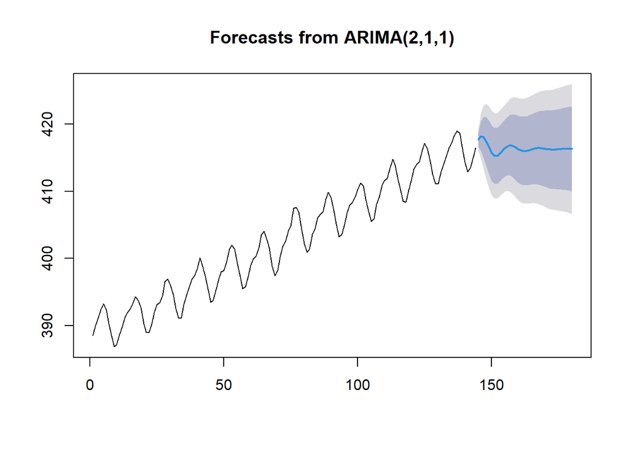

```r
data.ramalan <- ramalan$mean
plot(ramalan)
```

## Evaluasi Peramalan dengan model ARIMA(2,1,1)

### Tabel perbandingan

```r
perbandingan<-matrix(data=c(DataTest, data.ramalan),
                     nrow = nTest, ncol = 2)
colnames(perbandingan)<-c("Aktual","Hasil Forecast")
head(perbandingan)
```

```
##      Aktual Hasil Forecast
## [1,] 418.01       417.6679
## [2,] 418.99       418.2180
## [3,] 418.45       418.0520
## [4,] 420.01       417.3700
## [5,] 420.78       416.4910
## [6,] 420.68       415.7292
```

### Akurasi

```r
accuracy(data.ramalan, DataTest)
```

```
##                ME    RMSE      MAE      MPE    MAPE
## Test set 4.716272 5.69698 4.762079 1.114591 1.12562
```